# TP4 : Régression linéaire multiple, auto-corrélation spatiale et GWR

```python
import numpy as np
import pandas as pd
import geopandas as gpd
import matplotlib.pyplot as plt
```

## Données

### Chargement des contours des pays

```python
countries = gpd.read_file("countries.geojson")
```

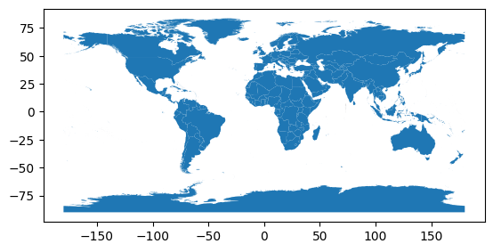

```python
countries.plot()
```

```python
countries
```

|  | name | ISO3166-1-Alpha-3 | ISO3166-1-Alpha-2 | geometry |
| --- | --- | --- | --- | --- |
| 0 | Indonesia | IDN | ID | MULTIPOLYGON (((117.70361 4.16342, 117.70361 4... |
| 1 | Malaysia | MYS | MY | MULTIPOLYGON (((117.70361 4.16342, 117.69711 4... |
| 2 | Chile | CHL | CL | MULTIPOLYGON (((-69.51009 -17.50659, -69.50611... |
| 3 | Bolivia | BOL | BO | POLYGON ((-69.51009 -17.50659, -69.51009 -17.5... |
| 4 | Peru | PER | PE | MULTIPOLYGON (((-69.51009 -17.50659, -69.63832... |
| ... | ... | ... | ... | ... |
| 253 | Macao S.A.R | MAC | MO | MULTIPOLYGON (((113.5586 22.16303, 113.56943 2... |
| 254 | Ashmore and Cartier Islands | -99 | -99 | POLYGON ((123.59702 -12.42832, 123.59775 -12.4... |
| 255 | Bajo Nuevo Bank (Petrel Is.) | -99 | -99 | POLYGON ((-79.98929 15.79495, -79.98782 15.796... |
| 256 | Serranilla Bank | -99 | -99 | POLYGON ((-78.63707 15.86209, -78.64041 15.864... |
| 257 | Scarborough Reef | -99 | -99 | POLYGON ((117.75389 15.15437, 117.75569 15.151... |

258 rows × 4 columns

```python
countries = countries.set_index("name")
```

```python
countries = countries.rename(index={
    "United States of America": "United States",
    "Democratic Republic of the Congo": "Democratic Republic of Congo",
    "Ivory Coast": "Cote d\'Ivoire",
    "Republic of the Congo": "Congo",
    "Czech Republic": "Czechia",
    "The Bahamas": "Bahamas",
    "Guinea Bissau": "Guinea-Bissau",
    "Federated States of Micronesia": "Micronesia (country)",
    "Macedonia": "North Macedonia",
    "eSwatini": "Eswatini",
    "Republic of Serbia": "Serbia",
    "United Republic of Tanzania": "Tanzania",
    "São Tomé and Principe": "Sao Tome and Principe",
    "Cape Verde": "Cabo Verde"
}
)
```

### Chargement des données

#### Cas 1: On a téléchargé des données pour une seule date

```python
life_expectancy = pd.read_csv("life-expectancy.csv")
```

```python
life_expectancy.head()
```

|  | Entity | Code | Year | Period life expectancy at birth | time |
| --- | --- | --- | --- | --- | --- |
| 0 | Afghanistan | AFG | 2023 | 66.0346 | 2023 |
| 1 | Albania | ALB | 2023 | 79.6019 | 2023 |
| 2 | Algeria | DZA | 2023 | 76.2610 | 2023 |
| 3 | Andorra | AND | 2023 | 84.0406 | 2023 |
| 4 | Angola | AGO | 2023 | 64.6170 | 2023 |

```python
life_expectancy = life_expectancy.set_index("Entity")
```

```python
life_expectancy.head()
```

| Entity | Code | Year | Period life expectancy at birth | time |
| --- | --- | --- | --- | --- |
| Afghanistan | AFG | 2023 | 66.0346 | 2023 |
| Albania | ALB | 2023 | 79.6019 | 2023 |
| Algeria | DZA | 2023 | 76.2610 | 2023 |
| Andorra | AND | 2023 | 84.0406 | 2023 |
| Angola | AGO | 2023 | 64.6170 | 2023 |

```python
countries["life_expectancy"]=np.arange(len(countries))
countries.head()
```

| name | ISO3166-1-Alpha-3 | ISO3166-1-Alpha-2 | geometry | life_expectancy |
| --- | --- | --- | --- | --- |
| Indonesia | IDN | ID | MULTIPOLYGON (((117.70361 4.16342, 117.70361 4... | 0 |
| Malaysia | MYS | MY | MULTIPOLYGON (((117.70361 4.16342, 117.69711 4... | 1 |
| Chile | CHL | CL | MULTIPOLYGON (((-69.51009 -17.50659, -69.50611... | 2 |
| Bolivia | BOL | BO | POLYGON ((-69.51009 -17.50659, -69.51009 -17.5... | 3 |
| Peru | PER | PE | MULTIPOLYGON (((-69.51009 -17.50659, -69.63832... | 4 |

```python
life_expectancy["Period life expectancy at birth"]
```

| Entity | Period life expectancy at birth |
| --- | --- |
| Afghanistan | 66.0346 |
| Albania | 79.6019 |
| Algeria | 76.2610 |
| Andorra | 84.0406 |
| Angola | 64.6170 |
| ... | ... |
| Vietnam | 74.5883 |
| Western Sahara | 71.3850 |
| Yemen | 69.2952 |
| Zambia | 66.3487 |
| Zimbabwe | 62.7748 |

201 rows × 1 columns

**dtype:** float64

```python
countries["life_expectancy"]=life_expectancy["Period life expectancy at birth"]
countries.head()
```

| name | ISO3166-1-Alpha-3 | ISO3166-1-Alpha-2 | geometry | life_expectancy |
| --- | --- | --- | --- | --- |
| Indonesia | IDN | ID | MULTIPOLYGON (((117.70361 4.16342, 117.70361 4... | 71.1457 |
| Malaysia | MYS | MY | MULTIPOLYGON (((117.70361 4.16342, 117.69711 4... | 76.6571 |
| Chile | CHL | CL | MULTIPOLYGON (((-69.51009 -17.50659, -69.50611... | 81.1667 |
| Bolivia | BOL | BO | POLYGON ((-69.51009 -17.50659, -69.51009 -17.5... | 68.5814 |
| Peru | PER | PE | MULTIPOLYGON (((-69.51009 -17.50659, -69.63832... | 77.7401 |

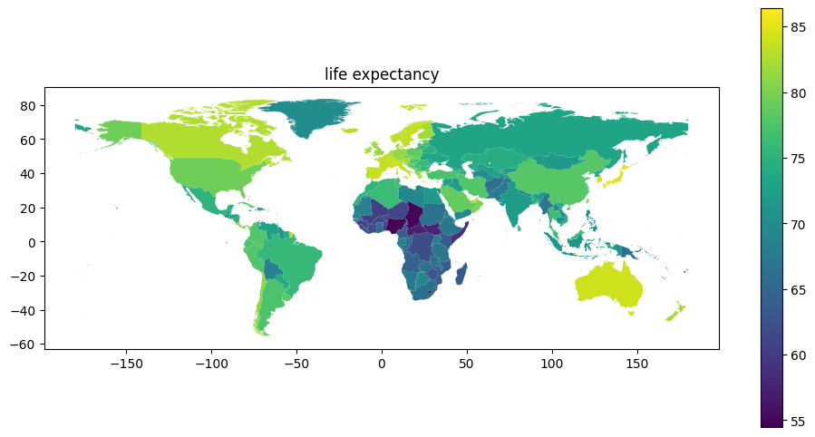

```python
countries.plot(column="life_expectancy", figsize=(12,6), legend=True).set_title("life expectancy")
```

On fait la même chose pour les autres variables étudiées

```python
countries["population"] = pd.read_csv("population.csv").set_index("Entity")["Population (historical)"]
```

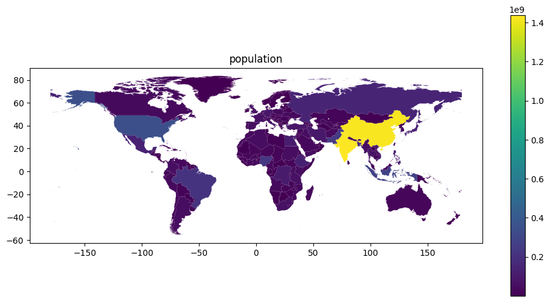

```python
countries.plot(column="population", figsize=(12,6), legend=True).set_title("population")
```

```python
countries["log_population"] = np.log(countries["population"])
```

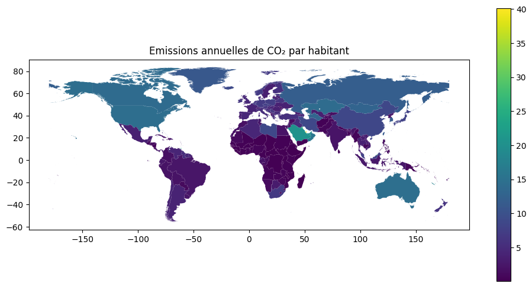

```python
countries["co2_emissions"] = pd.read_csv("co-emissions-per-capita.csv").set_index("Entity")["Annual CO₂ emissions (per capita)"]
countries.plot(column="co2_emissions", figsize=(12,6), legend=True).set_title("Emissions annuelles de CO₂ par habitant")
```

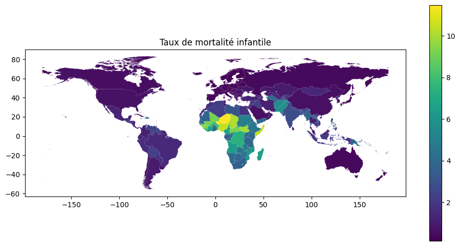

```python
countries["child_mortality"] = pd.read_csv("child-mortality.csv").set_index("Entity")["Child mortality rate"]
countries.plot(column="child_mortality", figsize=(12,6), legend=True).set_title("Taux de mortalité infantile")
```

```python
countries["log_child_mortality"] = np.log(1+countries["child_mortality"])
```

#### Cas 2 : on a téléchargé la série temporelle

```python
hdi = pd.read_csv("human-development-index.csv")
```

```python
hdi.head()
```

|  | Entity | Code | Year | Human Development Index | World regions according to OWID |
| --- | --- | --- | --- | --- | --- |
| 0 | Afghanistan | AFG | 1990 | 0.285 | NaN |
| 1 | Afghanistan | AFG | 1991 | 0.291 | NaN |
| 2 | Afghanistan | AFG | 1992 | 0.301 | NaN |
| 3 | Afghanistan | AFG | 1993 | 0.311 | NaN |
| 4 | Afghanistan | AFG | 1994 | 0.305 | NaN |

```python
hdi_by_year = hdi.pivot_table(index='Entity', columns='Year', values='Human Development Index')
hdi_by_year.head()
```

| Year Entity | 1990 | 1991 | 1992 | 1993 | 1994 | 1995 | 1996 | 1997 | 1998 | 1999 | ... | 2014 | 2015 | 2016 | 2017 | 2018 | 2019 | 2020 | 2021 | 2022 | 2023 |
| --- | --- | --- | --- | --- | --- | --- | --- | --- | --- | --- | --- | --- | --- | --- | --- | --- | --- | --- | --- | --- | --- |
| Afghanistan | 0.285 | 0.291 | 0.301 | 0.311 | 0.305 | 0.329 | 0.334 | 0.338 | 0.338 | 0.347 | ... | 0.497000 | 0.49600 | 0.495000 | 0.4960 | 0.498000 | 0.507000 | 0.501000 | 0.486000 | 0.495000 | 0.496000 |
| Africa | NaN | NaN | NaN | NaN | NaN | NaN | NaN | NaN | NaN | NaN | ... | 0.536723 | 0.54259 | 0.546639 | 0.5504 | 0.555833 | 0.560354 | 0.559465 | 0.561104 | 0.571485 | 0.576059 |
| Albania | 0.654 | 0.638 | 0.622 | 0.624 | 0.629 | 0.638 | 0.647 | 0.645 | 0.659 | 0.671 | ... | 0.797000 | 0.79700 | 0.797000 | 0.7980 | 0.801000 | 0.805000 | 0.794000 | 0.794000 | 0.806000 | 0.810000 |
| Algeria | 0.595 | 0.596 | 0.601 | 0.603 | 0.603 | 0.608 | 0.615 | 0.624 | 0.634 | 0.643 | ... | 0.732000 | 0.73700 | 0.743000 | 0.7460 | 0.749000 | 0.753000 | 0.742000 | 0.755000 | 0.761000 | 0.763000 |
| Andorra | NaN | NaN | NaN | NaN | NaN | NaN | NaN | NaN | NaN | NaN | ... | 0.866000 | 0.86900 | 0.872000 | 0.8730 | 0.875000 | 0.876000 | 0.851000 | 0.871000 | 0.893000 | 0.913000 |

5 rows × 34 columns

```python
def function_to_rename_columns_name(column_name):
    return f"hdi_{column_name}"

hdi_by_year = hdi_by_year.rename(columns=function_to_rename_columns_name)
hdi_by_year.head()
```

| Year Entity | hdi_1990 | hdi_1991 | hdi_1992 | hdi_1993 | hdi_1994 | hdi_1995 | hdi_1996 | hdi_1997 | hdi_1998 | hdi_1999 | ... | hdi_2014 | hdi_2015 | hdi_2016 | hdi_2017 | hdi_2018 | hdi_2019 | hdi_2020 | hdi_2021 | hdi_2022 | hdi_2023 |
| --- | --- | --- | --- | --- | --- | --- | --- | --- | --- | --- | --- | --- | --- | --- | --- | --- | --- | --- | --- | --- | --- |
| Afghanistan | 0.285 | 0.291 | 0.301 | 0.311 | 0.305 | 0.329 | 0.334 | 0.338 | 0.338 | 0.347 | ... | 0.497000 | 0.49600 | 0.495000 | 0.4960 | 0.498000 | 0.507000 | 0.501000 | 0.486000 | 0.495000 | 0.496000 |
| Africa | NaN | NaN | NaN | NaN | NaN | NaN | NaN | NaN | NaN | NaN | ... | 0.536723 | 0.54259 | 0.546639 | 0.5504 | 0.555833 | 0.560354 | 0.559465 | 0.561104 | 0.571485 | 0.576059 |
| Albania | 0.654 | 0.638 | 0.622 | 0.624 | 0.629 | 0.638 | 0.647 | 0.645 | 0.659 | 0.671 | ... | 0.797000 | 0.79700 | 0.797000 | 0.7980 | 0.801000 | 0.805000 | 0.794000 | 0.794000 | 0.806000 | 0.810000 |
| Algeria | 0.595 | 0.596 | 0.601 | 0.603 | 0.603 | 0.608 | 0.615 | 0.624 | 0.634 | 0.643 | ... | 0.732000 | 0.73700 | 0.743000 | 0.7460 | 0.749000 | 0.753000 | 0.742000 | 0.755000 | 0.761000 | 0.763000 |
| Andorra | NaN | NaN | NaN | NaN | NaN | NaN | NaN | NaN | NaN | NaN | ... | 0.866000 | 0.86900 | 0.872000 | 0.8730 | 0.875000 | 0.876000 | 0.851000 | 0.871000 | 0.893000 | 0.913000 |

5 rows × 34 columns

```python
countries[["hdi_2023", "hdi_2013"]]=hdi_by_year[["hdi_2023", "hdi_2013"]]
```

```python
countries
```

| name | ISO3166-1-Alpha-3 | ISO3166-1-Alpha-2 | geometry | life_expectancy | population | log_population | co2_emissions | child_mortality | log_child_mortality | hdi_2023 | hdi_2013 |
| --- | --- | --- | --- | --- | --- | --- | --- | --- | --- | --- | --- |
| Indonesia | IDN | ID | MULTIPOLYGON (((117.70361 4.16342, 117.70361 4... | 71.1457 | 281190068.0 | 19.454541 | 2.711182 | 2.06 | 1.118415 | 0.728 | 0.690 |
| Malaysia | MYS | MY | MULTIPOLYGON (((117.70361 4.16342, 117.69711 4... | 76.6571 | 35126295.0 | 17.374461 | 7.865810 | 0.81 | 0.593327 | 0.819 | 0.791 |
| Chile | CHL | CL | MULTIPOLYGON (((-69.51009 -17.50659, -69.50611... | 81.1667 | 19658833.0 | 16.794037 | 3.947550 | 0.72 | 0.542324 | 0.878 | 0.845 |
| Bolivia | BOL | BO | POLYGON ((-69.51009 -17.50659, -69.51009 -17.5... | 68.5814 | 12244161.0 | 16.320560 | 2.010797 | 2.31 | 1.196948 | 0.733 | 0.699 |
| Peru | PER | PE | MULTIPOLYGON (((-69.51009 -17.50659, -69.63832... | 77.7401 | 33845616.0 | 17.337320 | 1.951944 | 1.58 | 0.947789 | 0.794 | 0.757 |
| ... | ... | ... | ... | ... | ... | ... | ... | ... | ... | ... | ... |
| Macao S.A.R | MAC | MO | MULTIPOLYGON (((113.5586 22.16303, 113.56943 2... | NaN | NaN | NaN | NaN | NaN | NaN | NaN | NaN |
| Ashmore and Cartier Islands | -99 | -99 | POLYGON ((123.59702 -12.42832, 123.59775 -12.4... | NaN | NaN | NaN | NaN | NaN | NaN | NaN | NaN |
| Bajo Nuevo Bank (Petrel Is.) | -99 | -99 | POLYGON ((-79.98929 15.79495, -79.98782 15.796... | NaN | NaN | NaN | NaN | NaN | NaN | NaN | NaN |
| Serranilla Bank | -99 | -99 | POLYGON ((-78.63707 15.86209, -78.64041 15.864... | NaN | NaN | NaN | NaN | NaN | NaN | NaN | NaN |
| Scarborough Reef | -99 | -99 | POLYGON ((117.75389 15.15437, 117.75569 15.151... | NaN | NaN | NaN | NaN | NaN | NaN | NaN | NaN |

258 rows × 11 columns

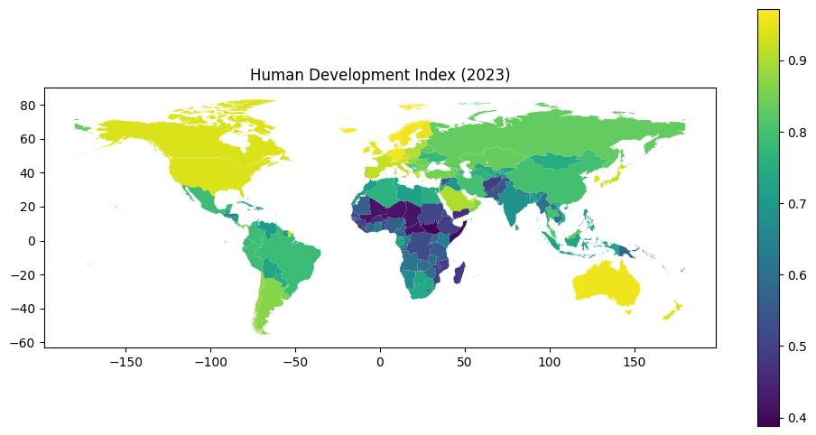

```python
countries.plot(column='hdi_2023', figsize=(12,6), legend=True).set_title("Human Development Index (2023)")
```

#### Gestion des valeurs NaN

La plupart des méthodes d'analyse statistiques ne supportent pas les NaN, par exemple l'ACP.

Si l'analyse de ces unités spatiales est importante, on peut leur attribuer une valeur, par exemple la moyenne pour chaque variable. Si les variables avec un NaN sont corrélées avec une variable pour laquelle la valeur est connue, on peut inférer avec une régression linéaire.

Dans notre cas, on va simplement ignorer les individus avec des NaN, avec la méthode `dropna()`.

```python
countries = countries.dropna()
countries
```

| name | ISO3166-1-Alpha-3 | ISO3166-1-Alpha-2 | geometry | life_expectancy | population | log_population | co2_emissions | child_mortality | log_child_mortality | hdi_2023 | hdi_2013 |
| --- | --- | --- | --- | --- | --- | --- | --- | --- | --- | --- | --- |
| Indonesia | IDN | ID | MULTIPOLYGON (((117.70361 4.16342, 117.70361 4... | 71.1457 | 281190068.0 | 19.454541 | 2.711182 | 2.06 | 1.118415 | 0.728 | 0.690 |
| Malaysia | MYS | MY | MULTIPOLYGON (((117.70361 4.16342, 117.69711 4... | 76.6571 | 35126295.0 | 17.374461 | 7.865810 | 0.81 | 0.593327 | 0.819 | 0.791 |
| Chile | CHL | CL | MULTIPOLYGON (((-69.51009 -17.50659, -69.50611... | 81.1667 | 19658833.0 | 16.794037 | 3.947550 | 0.72 | 0.542324 | 0.878 | 0.845 |
| Bolivia | BOL | BO | POLYGON ((-69.51009 -17.50659, -69.51009 -17.5... | 68.5814 | 12244161.0 | 16.320560 | 2.010797 | 2.31 | 1.196948 | 0.733 | 0.699 |
| Peru | PER | PE | MULTIPOLYGON (((-69.51009 -17.50659, -69.63832... | 77.7401 | 33845616.0 | 17.337320 | 1.951944 | 1.58 | 0.947789 | 0.794 | 0.757 |
| ... | ... | ... | ... | ... | ... | ... | ... | ... | ... | ... | ... |
| Nauru | NRU | NR | POLYGON ((166.93881 -0.49041, 166.95558 -0.497... | 62.1094 | 11900.0 | 9.384294 | 4.933193 | 0.89 | 0.636577 | 0.703 | 0.640 |
| Micronesia (country) | FSM | FM | MULTIPOLYGON (((163.02605 5.34089, 163.03045 5... | 67.1983 | 112646.0 | 11.632005 | 1.278669 | 2.31 | 1.196948 | 0.615 | 0.603 |
| Vanuatu | VUT | VU | MULTIPOLYGON (((169.84034 -20.1408, 169.86052 ... | 71.4769 | 320422.0 | 12.677394 | 0.588156 | 1.68 | 0.985817 | 0.621 | 0.592 |
| Palau | PLW | PW | MULTIPOLYGON (((134.2715 7.07453, 134.27931 7.... | 69.2690 | 17751.0 | 9.784197 | 12.180102 | 2.23 | 1.172482 | 0.786 | 0.791 |
| Bahrain | BHR | BH | MULTIPOLYGON (((50.55161 26.19424, 50.59474 26... | 81.2835 | 1569674.0 | 14.266379 | 24.710030 | 0.86 | 0.620576 | 0.899 | 0.846 |

188 rows × 11 columns

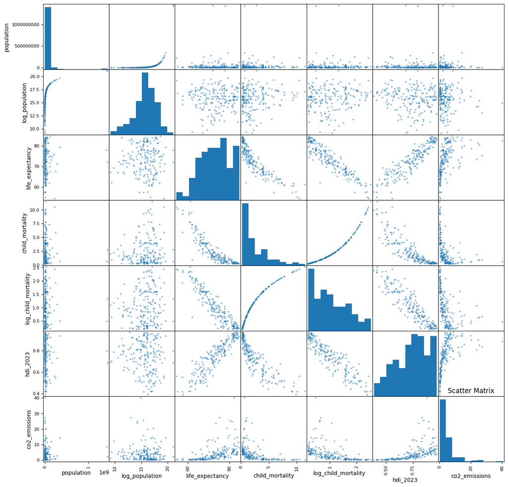

```python
pd.plotting.scatter_matrix(countries[["population", "log_population", "life_expectancy", "child_mortality", "log_child_mortality", "hdi_2023", "co2_emissions"]], figsize=(15, 15))
```

## 2) Régression linéaire multiple

On va essayer de prédire les emissions de CO2 du pays en fonctions des autres variables

```python
import statsmodels.api as sm
explicative_vars = ["population", "life_expectancy", "log_child_mortality", "hdi_2023"]
target = "co2_emissions"
X = sm.add_constant(countries[explicative_vars])
y = countries[target]
#Ordinary Least Square
model = sm.OLS(y, X)
results = model.fit()
print(results.summary())
```

```
                            OLS Regression Results
==============================================================================
Dep. Variable:          co2_emissions   R-squared:                       0.303
Model:                            OLS   Adj. R-squared:                  0.288
Method:                 Least Squares   F-statistic:                     19.86
Date:                Thu, 05 Mar 2026   Prob (F-statistic):           1.34e-13
Time:                        13:23:47   Log-Likelihood:                -554.61
No. Observations:                 188   AIC:                             1119.
Df Residuals:                     183   BIC:                             1135.
Df Model:                           4
Covariance Type:            nonrobust
=======================================================================================
                          coef    std err          t      P>|t|      [0.025      0.975]
---------------------------------------------------------------------------------------
const                 -23.6306     10.692     -2.210      0.028     -44.726      -2.535
population           5.968e-10   2.25e-09      0.265      0.791   -3.84e-09    5.03e-09
life_expectancy         0.0883      0.136      0.647      0.518      -0.181       0.357
log_child_mortality     2.4131      1.623      1.487      0.139      -0.789       5.615
hdi_2023               25.6472      6.123      4.188      0.000      13.566      37.729
==============================================================================
Omnibus:                      171.228   Durbin-Watson:                   1.660
Prob(Omnibus):                  0.000   Jarque-Bera (JB):             2597.328
Skew:                           3.515   Prob(JB):                         0.00
Kurtosis:                      19.797   Cond. No.                     5.02e+09
==============================================================================

Notes:
[1] Standard Errors assume that the covariance matrix of the errors is correctly specified.
[2] The condition number is large, 5.02e+09. This might indicate that there are
strong multicollinearity or other numerical problems.
```

```python
y_pred = results.predict(X)
countries["predicted_co2_emissions"] = y_pred
countries["residus"] = results.resid
```

```python
#calcul des valeurs min et max pour avoir une échelle commune
vmin = min(countries["co2_emissions"].min(), countries["predicted_co2_emissions"].min())
vmax = max(countries["co2_emissions"].max(), countries["predicted_co2_emissions"].max())
```

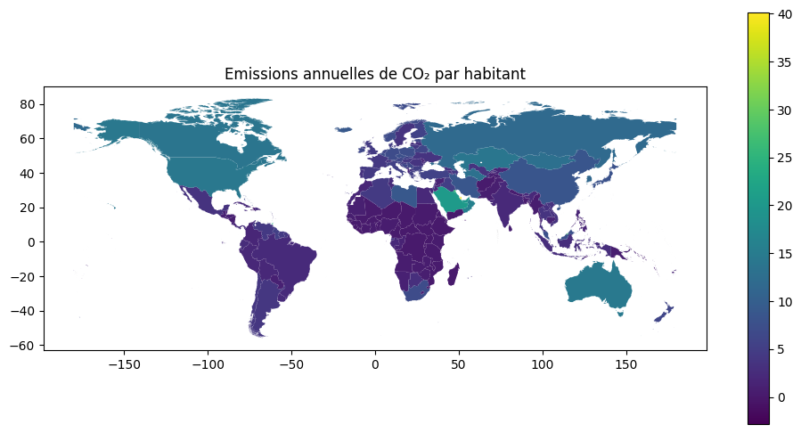

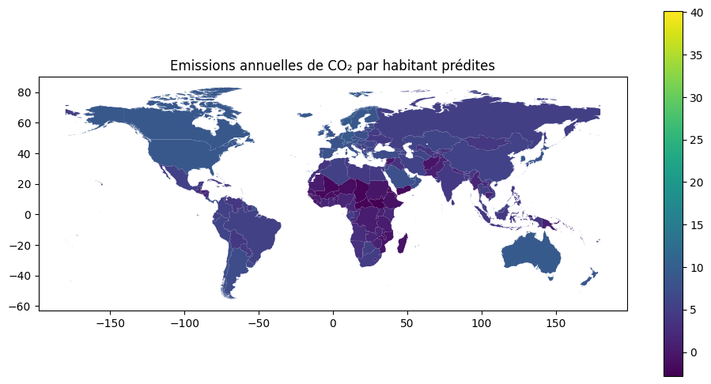

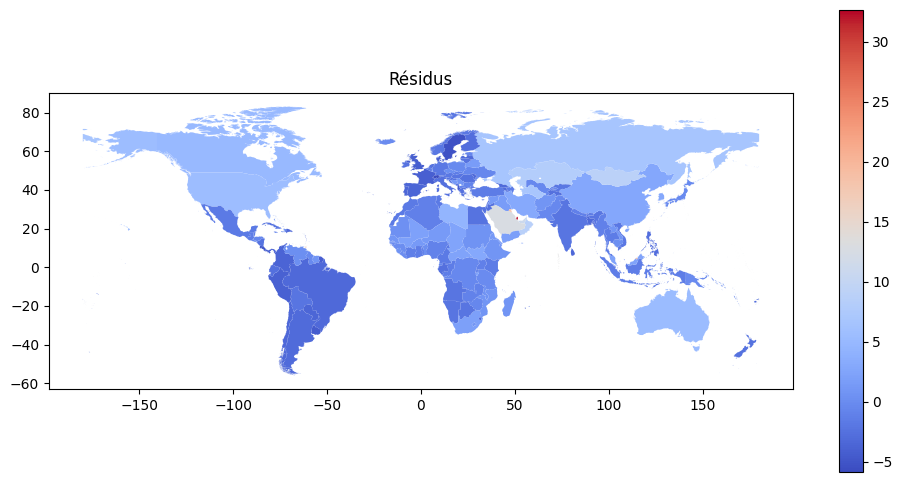

```python
countries.plot(column="co2_emissions", figsize=(12,6), legend=True, vmin=vmin, vmax=vmax).set_title("Emissions annuelles de CO₂ par habitant")
countries.plot(column="predicted_co2_emissions", figsize=(12,6), legend=True, vmin=vmin, vmax=vmax).set_title("Emissions annuelles de CO₂ par habitant prédites")
countries.plot(column="residus", figsize=(12,6), legend=True, cmap="coolwarm").set_title("Résidus")
```

- On peut voir que globalement les résidus ont l'air d'être autocorrélés spatiallement.
- Le Qatar a une valeur de résidu particulièrement élevée (émissions sous-estimées)

On va essayer en enlevant les pays "outliers"

```python
import statsmodels.api as sm
explicative_vars = ["population", "life_expectancy", "log_child_mortality", "hdi_2023"]
target = "co2_emissions"

countries_without_high_residus = countries[countries["residus"]<15]

X2 = sm.add_constant(countries_without_high_residus[explicative_vars])
y2 = countries_without_high_residus[target]
#Ordinary Least Square
model2 = sm.OLS(y2, X2)
results2 = model2.fit()
print(results2.summary())
```

```
                            OLS Regression Results
==============================================================================
Dep. Variable:          co2_emissions   R-squared:                       0.455
Model:                            OLS   Adj. R-squared:                  0.443
Method:                 Least Squares   F-statistic:                     37.21
Date:                Thu, 05 Mar 2026   Prob (F-statistic):           1.34e-22
Time:                        13:24:03   Log-Likelihood:                -448.35
No. Observations:                 183   AIC:                             906.7
Df Residuals:                     178   BIC:                             922.7
Df Model:                           4
Covariance Type:            nonrobust
=======================================================================================
                          coef    std err          t      P>|t|      [0.025      0.975]
---------------------------------------------------------------------------------------
const                  -9.3549      6.582     -1.421      0.157     -22.345       3.635
population           1.747e-09   1.37e-09      1.279      0.203   -9.49e-10    4.44e-09
life_expectancy        -0.0568      0.084     -0.678      0.499      -0.222       0.109
log_child_mortality     0.7364      0.994      0.741      0.460      -1.225       2.698
hdi_2023               22.1422      3.736      5.927      0.000      14.770      29.514
==============================================================================
Omnibus:                      101.890   Durbin-Watson:                   1.847
Prob(Omnibus):                  0.000   Jarque-Bera (JB):              456.080
Skew:                           2.217   Prob(JB):                    9.19e-100
Kurtosis:                       9.336   Cond. No.                     5.09e+09
==============================================================================

Notes:
[1] Standard Errors assume that the covariance matrix of the errors is correctly specified.
[2] The condition number is large, 5.09e+09. This might indicate that there are
strong multicollinearity or other numerical problems.
```

On voit qu'on a augmenté le R² : le modèle est mieux adapté sans ces valeurs extrêmes

```python
y_pred2 = results.predict(X)
countries["predicted_co2_emissions2"] = y_pred2
countries["residus2"] = countries["co2_emissions"] - countries["predicted_co2_emissions2"]
```

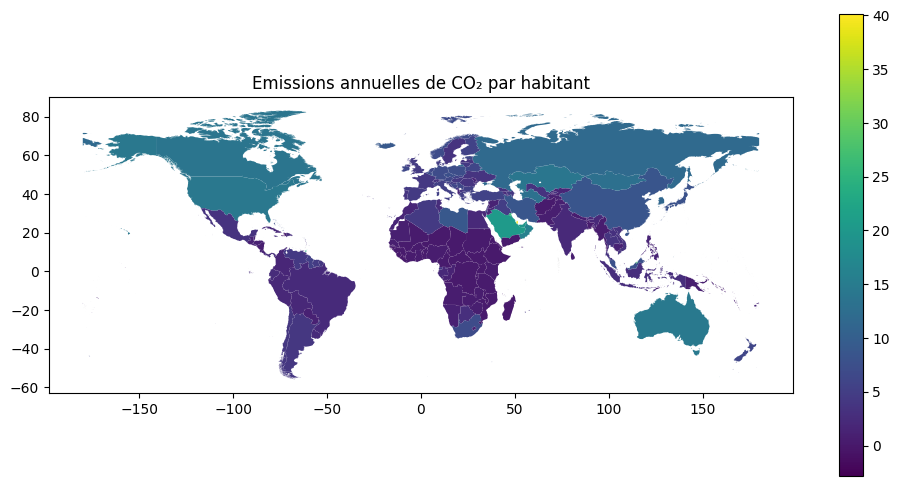

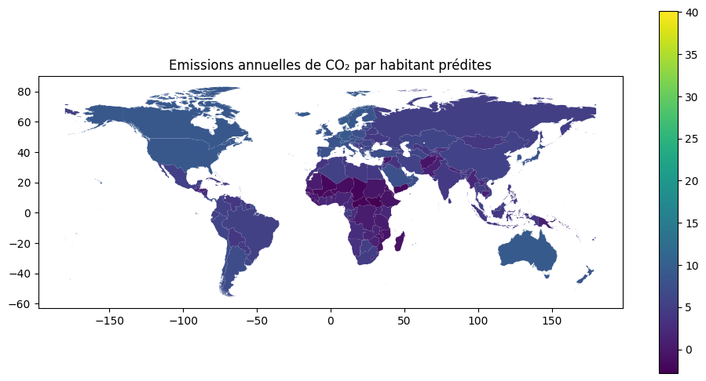

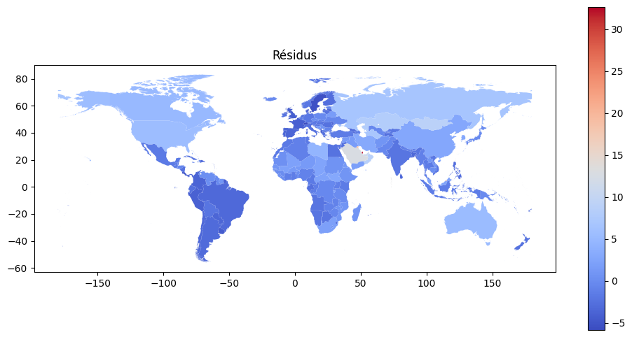

```python
#calcul des valeurs min et max pour avoir une échelle commune
vmin = min(countries["co2_emissions"].min(), countries["predicted_co2_emissions2"].min())
vmax = max(countries["co2_emissions"].max(), countries["predicted_co2_emissions2"].max())
countries.plot(column="co2_emissions", figsize=(12,6), legend=True, vmin=vmin, vmax=vmax).set_title("Emissions annuelles de CO₂ par habitant")
countries.plot(column="predicted_co2_emissions2", figsize=(12,6), legend=True, vmin=vmin, vmax=vmax).set_title("Emissions annuelles de CO₂ par habitant prédites")
countries.plot(column="residus2", figsize=(12,6), legend=True, cmap="coolwarm").set_title("Résidus")
```

Régression en enlevant les variables non significatives

```python
import statsmodels.api as sm
explicative_vars = ["hdi_2023"]
target = "co2_emissions"

countries_without_high_residus = countries[countries["residus"]<15]

X3 = sm.add_constant(countries_without_high_residus[explicative_vars])
y3 = countries_without_high_residus[target]
#Ordinary Least Square
model3 = sm.OLS(y2, X3)
results3 = model3.fit()
print(results3.summary())
```

```
                            OLS Regression Results
==============================================================================
Dep. Variable:          co2_emissions   R-squared:                       0.444
Model:                            OLS   Adj. R-squared:                  0.441
Method:                 Least Squares   F-statistic:                     144.4
Date:                Thu, 05 Mar 2026   Prob (F-statistic):           7.71e-25
Time:                        13:22:48   Log-Likelihood:                -450.27
No. Observations:                 183   AIC:                             904.5
Df Residuals:                     181   BIC:                             911.0
Df Model:                           1
Covariance Type:            nonrobust
==============================================================================
                 coef    std err          t      P>|t|      [0.025      0.975]
------------------------------------------------------------------------------
const         -8.7836      1.057     -8.308      0.000     -10.870      -6.697
hdi_2023      16.9033      1.406     12.018      0.000      14.128      19.678
==============================================================================
Omnibus:                      102.644   Durbin-Watson:                   1.807
Prob(Omnibus):                  0.000   Jarque-Bera (JB):              456.434
Skew:                           2.243   Prob(JB):                    7.70e-100
Kurtosis:                       9.304   Cond. No.                         10.4
==============================================================================

Notes:
[1] Standard Errors assume that the covariance matrix of the errors is correctly specified.
```

Les résultats sont légèrement moins bons (R² ajusté plus faible)

## 3) Autocorrélation spatiale

```python
W = countries.geometry.apply(lambda geom: countries.geometry.touches(geom)).astype(int)
```

```python
W
```

| name | Indonesia | Malaysia | Chile | Bolivia | Peru | Argentina | Cyprus | India | China | Israel | ... | Tonga | Samoa | Solomon Islands | Tuvalu | Maldives | Nauru | Micronesia (country) | Vanuatu | Palau | Bahrain |
| --- | --- | --- | --- | --- | --- | --- | --- | --- | --- | --- | --- | --- | --- | --- | --- | --- | --- | --- | --- | --- | --- |
| Indonesia | 0 | 1 | 0 | 0 | 0 | 0 | 0 | 0 | 0 | 0 | ... | 0 | 0 | 0 | 0 | 0 | 0 | 0 | 0 | 0 | 0 |
| Malaysia | 1 | 0 | 0 | 0 | 0 | 0 | 0 | 0 | 0 | 0 | ... | 0 | 0 | 0 | 0 | 0 | 0 | 0 | 0 | 0 | 0 |
| Chile | 0 | 0 | 0 | 1 | 1 | 1 | 0 | 0 | 0 | 0 | ... | 0 | 0 | 0 | 0 | 0 | 0 | 0 | 0 | 0 | 0 |
| Bolivia | 0 | 0 | 1 | 0 | 1 | 1 | 0 | 0 | 0 | 0 | ... | 0 | 0 | 0 | 0 | 0 | 0 | 0 | 0 | 0 | 0 |
| Peru | 0 | 0 | 1 | 1 | 0 | 0 | 0 | 0 | 0 | 0 | ... | 0 | 0 | 0 | 0 | 0 | 0 | 0 | 0 | 0 | 0 |
| ... | ... | ... | ... | ... | ... | ... | ... | ... | ... | ... | ... | ... | ... | ... | ... | ... | ... | ... | ... | ... | ... |
| Nauru | 0 | 0 | 0 | 0 | 0 | 0 | 0 | 0 | 0 | 0 | ... | 0 | 0 | 0 | 0 | 0 | 0 | 0 | 0 | 0 | 0 |
| Micronesia (country) | 0 | 0 | 0 | 0 | 0 | 0 | 0 | 0 | 0 | 0 | ... | 0 | 0 | 0 | 0 | 0 | 0 | 0 | 0 | 0 | 0 |
| Vanuatu | 0 | 0 | 0 | 0 | 0 | 0 | 0 | 0 | 0 | 0 | ... | 0 | 0 | 0 | 0 | 0 | 0 | 0 | 0 | 0 | 0 |
| Palau | 0 | 0 | 0 | 0 | 0 | 0 | 0 | 0 | 0 | 0 | ... | 0 | 0 | 0 | 0 | 0 | 0 | 0 | 0 | 0 | 0 |
| Bahrain | 0 | 0 | 0 | 0 | 0 | 0 | 0 | 0 | 0 | 0 | ... | 0 | 0 | 0 | 0 | 0 | 0 | 0 | 0 | 0 | 0 |

188 rows × 188 columns

Qui sont les voisins de la France ?

```python
voisins_france = W.loc["France"][W.loc["France"]==1]
voisins_france
```

| name | France |
| --- | --- |
| Suriname | 1 |
| Brazil | 1 |
| Germany | 1 |
| Luxembourg | 1 |
| Belgium | 1 |
| Spain | 1 |
| Italy | 1 |
| Switzerland | 1 |
| Andorra | 1 |

**dtype:** int64

Les valeurs de la variable sont-elles similaires pour la France et ses voisins ?

```python
print(countries.loc["France"][target])
print(countries.loc[voisins_france.index][target])
```

```
4.067842
name
Suriname        4.561335
Brazil          2.292272
Germany         7.022808
Luxembourg     10.285255
Belgium         7.231636
Spain           4.497049
Italy           5.248631
Switzerland     3.604899
Andorra         5.170065
Name: co2_emissions, dtype: float64
```

```python
Wtilde = W/W.sum(axis=0)
x = countries[target]
xc = x - x.mean()
```

```python
Wtilde = Wtilde.fillna(0)
```

Diagramme de Moran

[output not shown]

**dtype:** float64

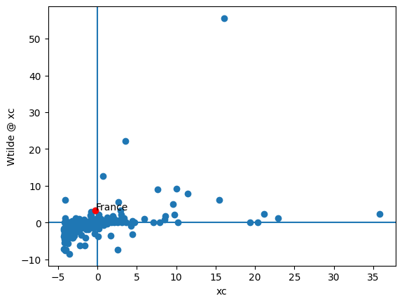

```python
plt.scatter(xc, Wtilde @ xc)
plt.xlabel("xc")
plt.ylabel("Wtilde @ xc")
plt.axvline(0)
plt.axhline(0)

#Afficher le point de la France
plt.plot(xc.loc["France"], (Wtilde @ xc).loc["France"], "or")
plt.text(xc.loc["France"], (Wtilde @ xc).loc["France"], "France")
```

Les emissions de CO2 de la France sont légèrement en dessous de la moyenne mondiale, tandis que celles de ces voisins sont au dessus de la moyenne mondiale

```python
Ii = xc * (Wtilde @ xc) / x.var()
```

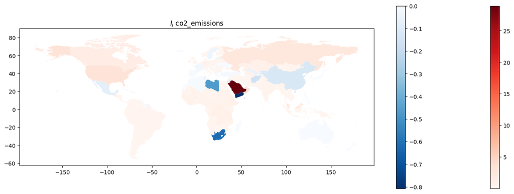

```python
countries["$I_i$ "+target] = Ii
ax = countries[countries["$I_i$ "+target]>0].plot(column="$I_i$ "+target, figsize=(18,6), legend=True, cmap="Reds")
countries[countries["$I_i$ "+target]<=0].plot(column="$I_i$ "+target, figsize=(18,6), legend=True, cmap="Blues_r", ax=ax)
ax.set_title("$I_i$ "+target)
```

```python
I = Ii.sum()/Wtilde.sum().sum()
I
```

```
np.float64(0.48546924209009396)
```

Ici, I est supérieur à 0 : globalement les émissions de CO2 d'un pays ressemblent à celles de ces voisins, mais ce n'est pas toujours le cas

```python
def compute_I(var):
    x = countries[var]
    xc = x - x.mean()
    Ii = xc * (Wtilde @ xc) / x.var()
    ax = countries[Ii>0].plot(column=Ii[Ii>0], figsize=(18,6), legend=True, cmap="Reds")
    countries[Ii<=0].plot(ax=ax, column=Ii[Ii<=0], legend=True, cmap="Blues_r").set_title("I_i "+ var)
    I = Ii.sum()/Wtilde.sum().sum()
    return I
```

```
hdi_2023 0.810427511484669
co2_emissions 0.48546924209009396
residus 0.4365841553095059
```

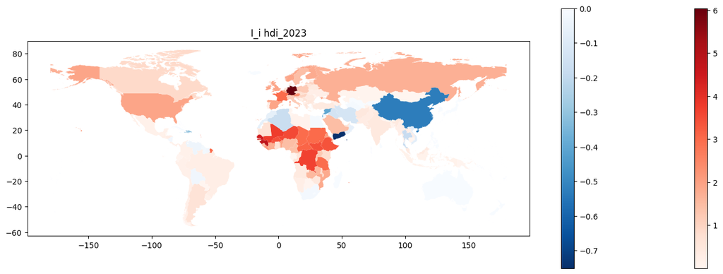

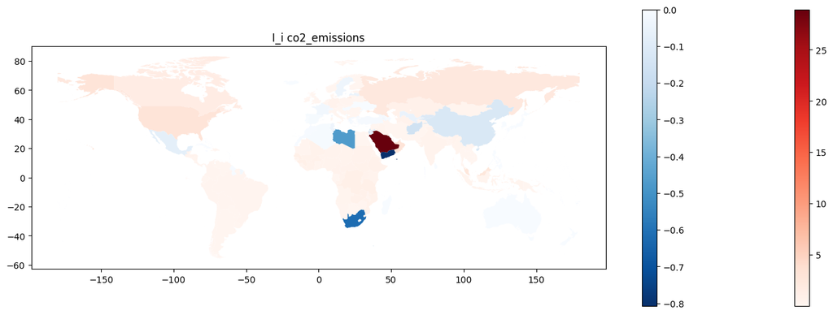

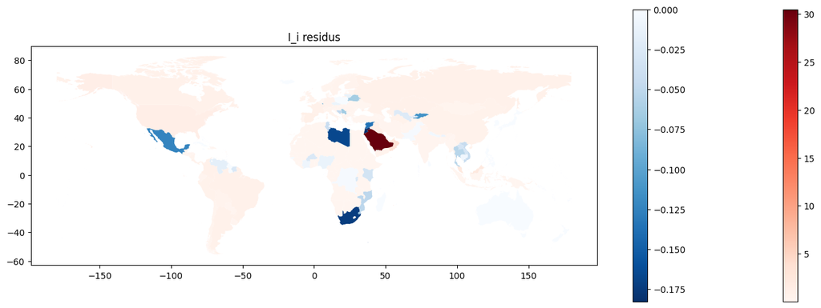

```python
for var in explicative_vars:
    print(var, compute_I(var))
print("co2_emissions", compute_I(target))
print("residus", compute_I("residus"))
```

On peut constater que l'IDH est très auto-corrélé spatialement (I proche de 1)

Les résidus ont une auto-corrélation non nulle : cela justifie le fait d'utiliser une GWR

## 4) GWR

```python
def distances(pays_cible):
    R = 6371000
    #On calcule les centroides en coordonnées projetées
    pays_cible = countries.to_crs(epsg="3857").loc[pays_cible]
    centroid_cible = pays_cible.geometry.centroid
    centroid_cible = gpd.GeoSeries([centroid_cible], crs="EPSG:3857").to_crs(epsg="4326")#On retourne sur les coordonnées lat lon
    centroids = countries.to_crs(epsg="3857").geometry.centroid.to_crs(epsg="4326")

    #On calcule les distances avec la formule de Haversine
    lat1 = centroid_cible.y * np.pi/180
    lon1 = centroid_cible.x * np.pi/180
    lat2 = centroids.y * np.pi/180
    lon2 = centroids.x * np.pi/180
    delta_lat = lat1.values - lat2.values
    delta_lon = lon1.values - lon2.values
    a = np.sin(delta_lat/2)**2 + np.cos(lat1.values) * np.cos(lat2.values) * np.sin(delta_lon/2)**2
    distances = 2*R*np.arcsin(np.sqrt(a))
    return pd.Series(distances, index=centroids.index)
distances("France").sort_values()
```

| name | 0 |
| --- | --- |
| France | 0.000000e+00 |
| Andorra | 2.887777e+05 |
| Spain | 4.692477e+05 |
| Portugal | 7.890318e+05 |
| Switzerland | 7.917678e+05 |
| ... | ... |
| Samoa | 1.652552e+07 |
| Fiji | 1.671480e+07 |
| Vanuatu | 1.673755e+07 |
| Tonga | 1.727393e+07 |
| New Zealand | 1.936601e+07 |

188 rows × 1 columns

**dtype:** float64

```python
#fonction Kernel
def K(x):
    return np.exp(-0.5*x**2)
```

```python
def w(pays_1, pays_2, h):
    distances_pays1 = distances(pays_1)
    d = distances_pays1.loc[pays_2]
    return K(d/h)
```

```python
print(w("France", "Spain", 1000000))#h = 1000km
print(w("France", "Chile", 1000000))
```

```
0.895747518969046
1.38397335406039e-30
```

```python
def Wi(pays_cible, h):
    distances_pays_cible = distances(pays_cible)
    wik = K(distances_pays_cible/h)
    return pd.DataFrame(np.diag(wik), index=wik.index, columns=wik.index)
Wi("France", 1000000)
```

| name | Indonesia | Malaysia | Chile | Bolivia | Peru | Argentina | Cyprus | India | China | Israel | ... | Tonga | Samoa | Solomon Islands | Tuvalu | Maldives | Nauru | Micronesia (country) | Vanuatu | Palau | Bahrain |
| --- | --- | --- | --- | --- | --- | --- | --- | --- | --- | --- | --- | --- | --- | --- | --- | --- | --- | --- | --- | --- | --- |
| Indonesia | 3.307843e-34 | 0.000000e+00 | 0.000000e+00 | 0.000000e+00 | 0.000000e+00 | 0.0 | 0.0 | 0.0 | 0.0 | 0.0 | ... | 0.0 | 0.0 | 0.0 | 0.0 | 0.0 | 0.000000e+00 | 0.000000e+00 | 0.000000e+00 | 0.000000e+00 | 0.000000 |
| Malaysia | 0.000000e+00 | 1.036276e-28 | 0.000000e+00 | 0.000000e+00 | 0.000000e+00 | 0.0 | 0.0 | 0.0 | 0.0 | 0.0 | ... | 0.0 | 0.0 | 0.0 | 0.0 | 0.0 | 0.000000e+00 | 0.000000e+00 | 0.000000e+00 | 0.000000e+00 | 0.000000 |
| Chile | 0.000000e+00 | 0.000000e+00 | 1.383973e-30 | 0.000000e+00 | 0.000000e+00 | 0.0 | 0.0 | 0.0 | 0.0 | 0.0 | ... | 0.0 | 0.0 | 0.0 | 0.0 | 0.0 | 0.000000e+00 | 0.000000e+00 | 0.000000e+00 | 0.000000e+00 | 0.000000 |
| Bolivia | 0.000000e+00 | 0.000000e+00 | 0.000000e+00 | 1.230765e-19 | 0.000000e+00 | 0.0 | 0.0 | 0.0 | 0.0 | 0.0 | ... | 0.0 | 0.0 | 0.0 | 0.0 | 0.0 | 0.000000e+00 | 0.000000e+00 | 0.000000e+00 | 0.000000e+00 | 0.000000 |
| Peru | 0.000000e+00 | 0.000000e+00 | 0.000000e+00 | 0.000000e+00 | 5.888055e-20 | 0.0 | 0.0 | 0.0 | 0.0 | 0.0 | ... | 0.0 | 0.0 | 0.0 | 0.0 | 0.0 | 0.000000e+00 | 0.000000e+00 | 0.000000e+00 | 0.000000e+00 | 0.000000 |
| ... | ... | ... | ... | ... | ... | ... | ... | ... | ... | ... | ... | ... | ... | ... | ... | ... | ... | ... | ... | ... | ... |
| Nauru | 0.000000e+00 | 0.000000e+00 | 0.000000e+00 | 0.000000e+00 | 0.000000e+00 | 0.0 | 0.0 | 0.0 | 0.0 | 0.0 | ... | 0.0 | 0.0 | 0.0 | 0.0 | 0.0 | 9.870316e-50 | 0.000000e+00 | 0.000000e+00 | 0.000000e+00 | 0.000000 |
| Micronesia (country) | 0.000000e+00 | 0.000000e+00 | 0.000000e+00 | 0.000000e+00 | 0.000000e+00 | 0.0 | 0.0 | 0.0 | 0.0 | 0.0 | ... | 0.0 | 0.0 | 0.0 | 0.0 | 0.0 | 0.000000e+00 | 1.997287e-42 | 0.000000e+00 | 0.000000e+00 | 0.000000 |
| Vanuatu | 0.000000e+00 | 0.000000e+00 | 0.000000e+00 | 0.000000e+00 | 0.000000e+00 | 0.0 | 0.0 | 0.0 | 0.0 | 0.0 | ... | 0.0 | 0.0 | 0.0 | 0.0 | 0.0 | 0.000000e+00 | 0.000000e+00 | 1.469473e-61 | 0.000000e+00 | 0.000000 |
| Palau | 0.000000e+00 | 0.000000e+00 | 0.000000e+00 | 0.000000e+00 | 0.000000e+00 | 0.0 | 0.0 | 0.0 | 0.0 | 0.0 | ... | 0.0 | 0.0 | 0.0 | 0.0 | 0.0 | 0.000000e+00 | 0.000000e+00 | 0.000000e+00 | 3.620417e-36 | 0.000000 |
| Bahrain | 0.000000e+00 | 0.000000e+00 | 0.000000e+00 | 0.000000e+00 | 0.000000e+00 | 0.0 | 0.0 | 0.0 | 0.0 | 0.0 | ... | 0.0 | 0.0 | 0.0 | 0.0 | 0.0 | 0.000000e+00 | 0.000000e+00 | 0.000000e+00 | 0.000000e+00 | 0.000003 |

188 rows × 188 columns

```python
def Betas_i(pays_cible, h):
    Wi_pays_cible = Wi(pays_cible, h)
    return np.linalg.solve(X.T @ Wi_pays_cible @ X, X.T @ Wi_pays_cible @ y)
```

```python
Betas_i("France", 1000000)
```

```
array([ 1.25866334e+01, -7.28745501e-09, -2.52405679e-01, -2.33875524e+00,
        1.56641687e+01])
```

On obtient les coefficients de la régression linéaire pour la France, qu'on peut comparer à ceux de la régression globale :

```python
results.params
```

|  | 0 |
| --- | --- |
| const | -2.363059e+01 |
| population | 5.968180e-10 |
| life_expectancy | 8.826256e-02 |
| log_child_mortality | 2.413059e+00 |
| hdi_2023 | 2.564717e+01 |

**dtype:** float64

```python
def predire(pays_cible, h):
    Betas_i_pays_cible = Betas_i(pays_cible, h)
    return (X @ Betas_i_pays_cible).loc[pays_cible]
```

```python
predire("France", 1000000)
```

```
np.float64(4.645206727664256)
```

```python
countries.loc["France", target]
```

```
np.float64(4.067842)
```

On est très proche !

```python
y_pred = [predire(pays, 1000000) for pays in countries.index]
```

```python
countries["predicted_co2_emissions_gwr"] = y_pred
```

```python
residus = countries["co2_emissions"] - countries["predicted_co2_emissions_gwr"]
```

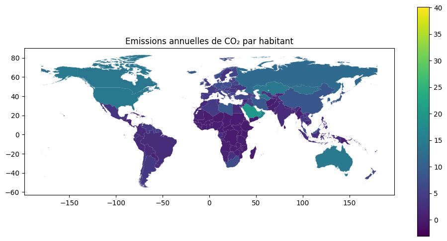

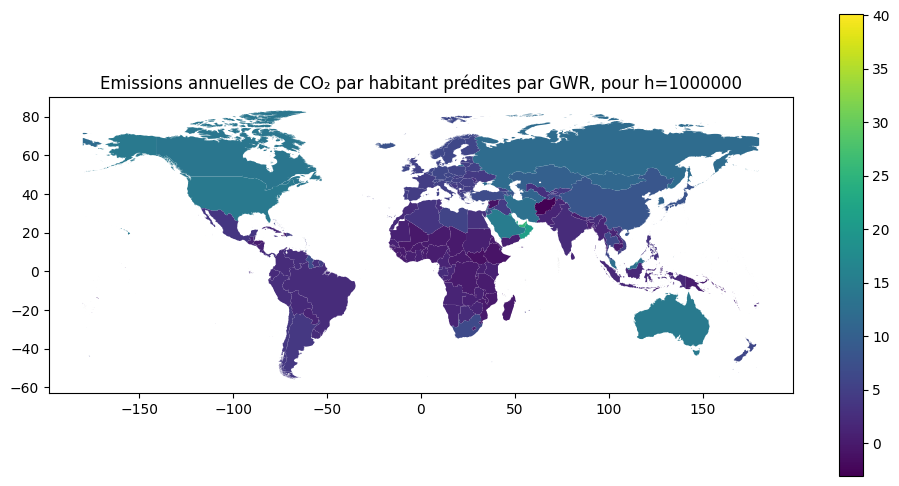

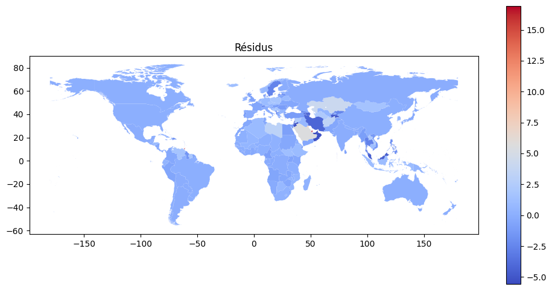

```python
vmin = min(countries["co2_emissions"].min(), countries["predicted_co2_emissions_gwr"].min())
vmax = max(countries["co2_emissions"].max(), countries["predicted_co2_emissions_gwr"].max())
countries.plot(column="co2_emissions", figsize=(12,6), legend=True, vmin=vmin, vmax=vmax).set_title("Emissions annuelles de CO₂ par habitant")
countries.plot(column="predicted_co2_emissions_gwr", figsize=(12,6), legend=True, vmin=vmin, vmax=vmax).set_title("Emissions annuelles de CO₂ par habitant prédites par GWR, pour h=1000000")
countries.plot(column=residus, figsize=(12,6), legend=True, cmap="coolwarm").set_title("Résidus")
```

Calcul du R² et du RMSE

```python
sum_of_squares_errors = (residus**2).sum()
RMSE = np.sqrt(sum_of_squares_errors/len(countries))
print(RMSE)
```

```
2.4714162052837563
```

```python
sum_of_squares_distance_to_mean = ((countries[target]-countries[target].mean())**2).sum()
R_2 = 1 - sum_of_squares_errors / sum_of_squares_distance_to_mean
print(R_2)
```

```
0.800751344305064
```

```python
Adjusted_R_2 = 1 - (1 - R_2) * (len(countries) - 1) / (len(countries) - X.shape[1] - 1)
print(Adjusted_R_2)
```

```
0.7952774801376207
```

On voit que les résultats de la GWR sont biens meilleurs que ceux de la régression globale, car elle s'adapte au contexte local

Carte des betas

```python
betas_i_all_countries = [Betas_i(pays, 1000000) for pays in countries.index]
```

```python
gdf_betas_i_all_countries = gpd.GeoDataFrame(
    betas_i_all_countries,
    index=countries.index,
    columns=X.columns,
    geometry=countries.geometry
)
```

```python
gdf_betas_i_all_countries
```

| name | const | population | life_expectancy | log_child_mortality | hdi_2023 | geometry |
| --- | --- | --- | --- | --- | --- | --- |
| Indonesia | 266.116496 | -4.312500e-08 | -4.190585 | -28.178468 | 106.246494 | MULTIPOLYGON (((117.70361 4.16342, 117.70361 4... |
| Malaysia | 240.994841 | -5.098763e-08 | -4.208162 | -19.270307 | 131.076197 | MULTIPOLYGON (((117.70361 4.16342, 117.69711 4... |
| Chile | -67.635768 | -8.604978e-09 | 0.166714 | 12.428998 | 58.611579 | MULTIPOLYGON (((-69.51009 -17.50659, -69.50611... |
| Bolivia | -19.550895 | 1.265115e-09 | -0.112319 | 3.579118 | 34.188579 | POLYGON ((-69.51009 -17.50659, -69.51009 -17.5... |
| Peru | -4.188316 | -8.626947e-09 | -0.215201 | 1.480612 | 28.110437 | MULTIPOLYGON (((-69.51009 -17.50659, -69.63832... |
| ... | ... | ... | ... | ... | ... | ... |
| Nauru | 17.092764 | -3.923703e-08 | -0.338677 | -0.694999 | 13.095048 | POLYGON ((166.93881 -0.49041, 166.95558 -0.497... |
| Micronesia (country) | -21.695788 | 2.087967e-08 | 0.049062 | -1.182948 | 34.391673 | MULTIPOLYGON (((163.02605 5.34089, 163.03045 5... |
| Vanuatu | 16.979232 | 2.980912e-07 | -0.255604 | -3.199578 | 7.853731 | MULTIPOLYGON (((169.84034 -20.1408, 169.86052 ... |
| Palau | -1.895352 | -4.024749e-08 | -0.099196 | -10.408483 | 42.271629 | MULTIPOLYGON (((134.2715 7.07453, 134.27931 7.... |
| Bahrain | -175.934514 | -1.592962e-08 | 2.032739 | 13.850842 | 28.074399 | MULTIPOLYGON (((50.55161 26.19424, 50.59474 26... |

188 rows × 6 columns

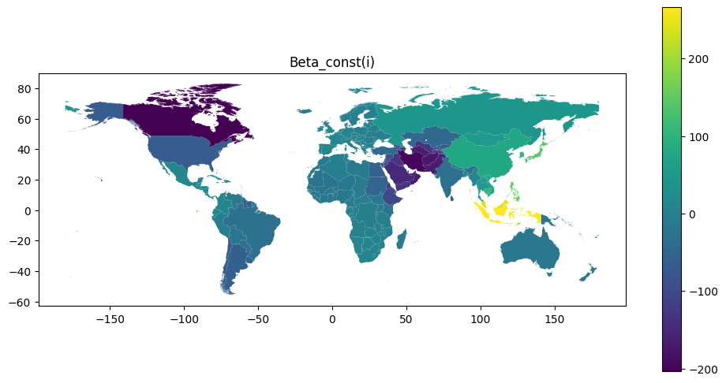

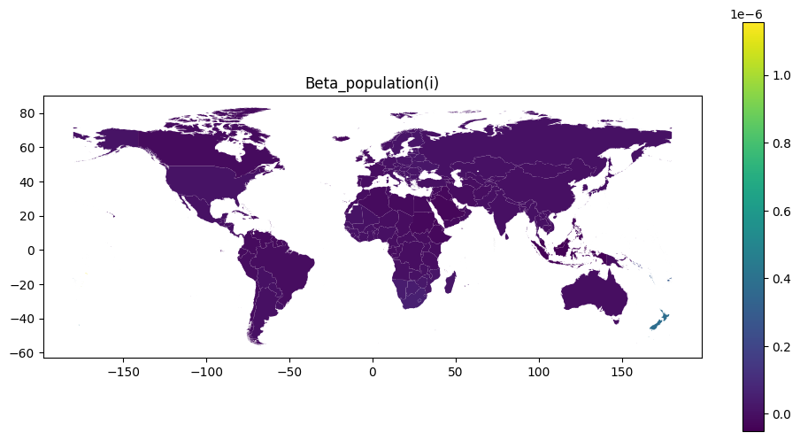

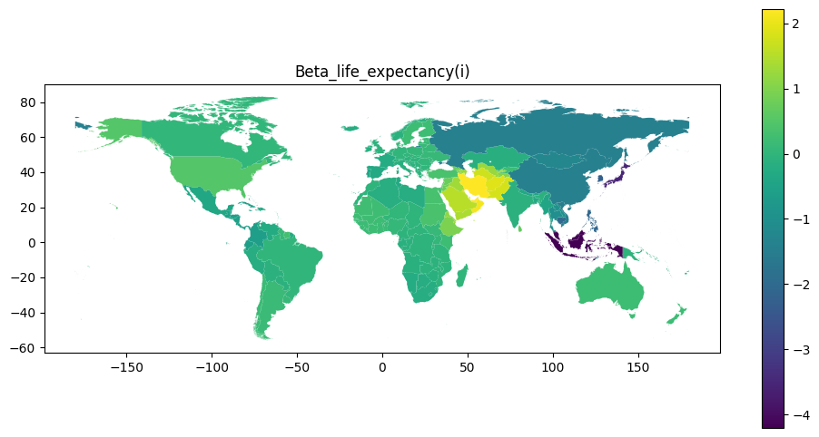

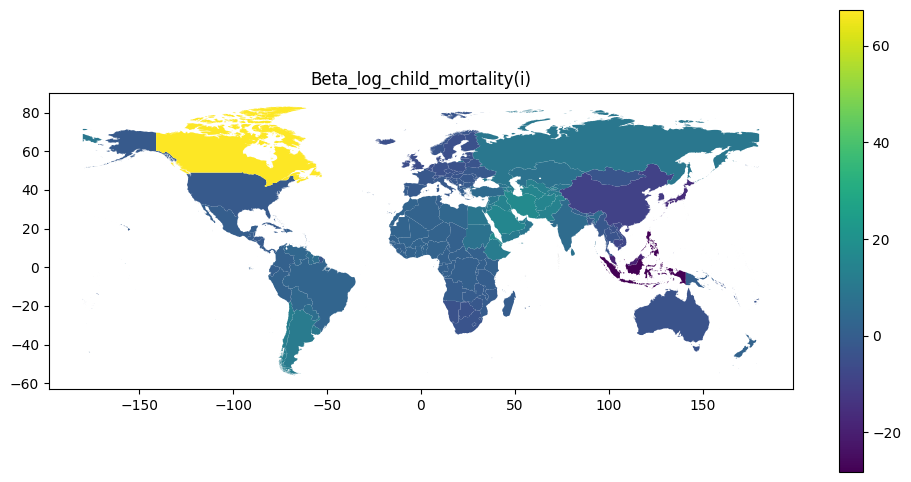

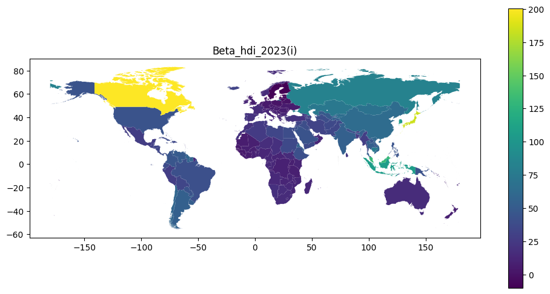

```python
for var in X.columns:
    gdf_betas_i_all_countries.plot(column=var, figsize=(12,6), legend=True).set_title(
       f"Beta_{var}(i)"
    )
```

Impact du changement de valeur de bande passante h

```python
y_pred = [predire(pays, 5000000) for pays in countries.index] # h=5000km
```

```python
countries["predicted_co2_emissions_gwr"] = y_pred
```

```python
residus = countries["co2_emissions"] - countries["predicted_co2_emissions_gwr"]
```

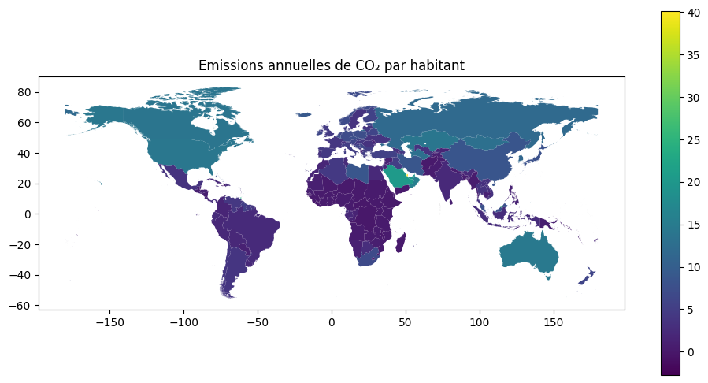

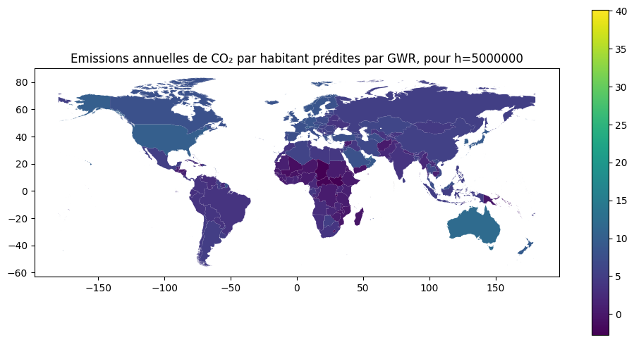

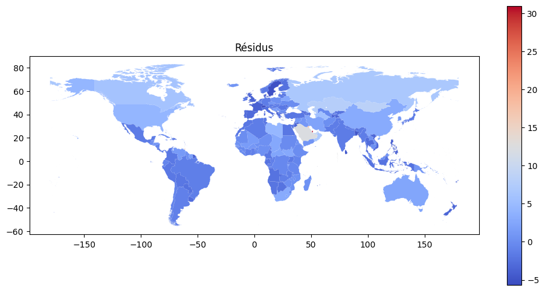

```python
vmin = min(countries["co2_emissions"].min(), countries["predicted_co2_emissions_gwr"].min())
vmax = max(countries["co2_emissions"].max(), countries["predicted_co2_emissions_gwr"].max())
countries.plot(column="co2_emissions", figsize=(12,6), legend=True, vmin=vmin, vmax=vmax).set_title("Emissions annuelles de CO₂ par habitant")
countries.plot(column="predicted_co2_emissions_gwr", figsize=(12,6), legend=True, vmin=vmin, vmax=vmax).set_title("Emissions annuelles de CO₂ par habitant prédites par GWR, pour h=5000000")
countries.plot(column=residus, figsize=(12,6), legend=True, cmap="coolwarm").set_title("Résidus")
```